# Mixed Effects Model

# Introduction

Generate data using random intercept and slope model. Fit mixed model using *lmer* and extract the variance of the random slopes. Compare with true value.

Some general parameters:

```r
# Number of simulations
nsim <- 1000
```

## Data

Data will be time series of length $T$ for each subject $i = 1, \dots, N$ with $N = 50$. Hence we have repeated measures within subjects. More formally, we use the following GLM:
$$Y_i = (\beta_0 + b_{0i}) + (\beta_1 + b_{1i})X + \varepsilon_i,$$
with $b_{0i} \sim N(0, 1)$, $b_{1i} \sim N(0, \sigma^2_{b})$ and $\varepsilon_i \sim N(0, \sigma^2_e)$. We see that we use the same design matrix $X$ for each subject and we only generate Gaussian random (white) noise. Furthermore, we set $\sigma^2_{b} = \in \{0,5^2\}$ and $\sigma^2_{e} = 6^2$. Finally, we have $\beta_0 = 100$ and $\beta_1 = 3$.

Note that we run the simulations two times for two values of $\sigma^2_{b}$!

## True values

The true values are hence:

```r
# Number of subjects
nsub <- 50

# True beta's
BETA0 <- 100
BETA1 <- 3

# Value for sigma, sigma of random slopes and intercepts
sigma_eps <- 6
sigma_b1 <- 1
sigma_b2 <- c(0,5)
```

Next, we set some parameters for the time series:

```r
# Signal characteristics
TR <- 2
nscan <- 200
total <- TR*nscan
on1 <- seq(1,total,40)
onsets <- list(on1)
duration <- list(20)

#######################################
#### DESIGN AND SIGNAL TIME SERIES ####
#######################################

# Generating a design matrix: convolution of block design with double-gamma HRF
X <- neuRosim::simprepTemporal(total,1,onsets = onsets,
                               effectsize = 1, durations = duration,
                               TR = TR, acc = 0.1, hrf = "double-gamma")

# X vector for one subject = predicted signal
X_s <- neuRosim::simTSfmri(design=X, base=0, SNR=1, noise="none", verbose=FALSE)
```

### Variance of parameter estimates

Let us calculate the variances of $\beta_1$. We do this following:

```r
# Calculate the true var(beta1)
TrueVarCovBeta <- data.frame() %>% as_tibble()

# Loop over the values for sigma of random slope
for(j in 1:length(sigma_b2)){
  var_cov_D_l <- rbind(c(sigma_b1**2, 0), c(0, sigma_b2[j]**2))
  # True variance-covariance matrix of beta
  V_mat <- cbind(1,X_s) %*% var_cov_D_l %*% t(cbind(1,X_s)) +
    diag(sigma_eps^2, nrow = nscan)
  varCovBeta <- solve(t(cbind(1,X_s)) %*% solve(V_mat) %*% cbind(1,X_s))
  # Add to data frame
  TrueVarCovBeta <- data.frame(True_sigma_b1 = sigma_b2[j],
             True_var_beta1 = varCovBeta[2,2]) %>%
    bind_rows(TrueVarCovBeta,.)
}
```

## Example data

Let us generate the time series all subject. To generate random intercept and slopes, we first generate subject-specific values for $b_{i0}$ and $b_{1i}$ where we set $\sigma^2_b = 5^2$ using a variance-covariance matrix:

```r
var_cov_D <- rbind(c(sigma_b1**2, 0), c(0, sigma_b2[2]**2))

# Generate the subject-specific values for intercept and slope using this D-matrix
B_matrix <- MASS::mvrnorm(nsub, mu=c(0,0), Sigma = var_cov_D)
```

Now looping over all subjects, we have:

```r
# Empty vector
Y <- data.frame() %>% as_tibble()

# For loop over all subjects
for(i in 1:nsub){
  # Generate nscan values, corresponding to time series of one subject
    # note: random intercept and random slope generated earlier
  Y_s <- (BETA0 + B_matrix[i,1]) + ((BETA1 + B_matrix[i,2]) * X_s) +
    rnorm(n = nscan, mean = 0, sd = sigma_eps)

  # Add to data frame
  Y <- data.frame(Y = Y_s, X = X_s, sub = as.integer(i)) %>% as_tibble() %>%
    bind_rows(Y, .)
}
```

Let us plot the time series for one subject (red line is true response for this subject).

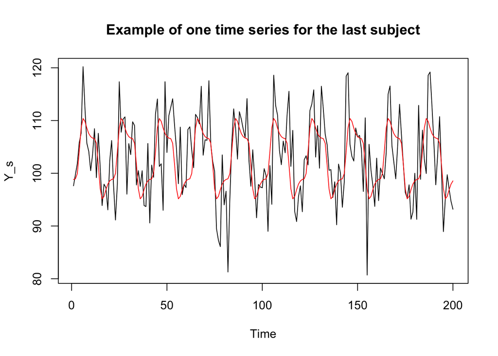

```r
plot(Y_s, type = 'l', main = 'Example of one time series for the last subject',
     xlab = 'Time')
lines(x = ((BETA0 + B_matrix[nsub,1]) + ((BETA1 + B_matrix[nsub,2]) * X_s)), col = 'red')
```

The analysis of the time series of all $N$ subjects using **R** is straightforward:

```r
lmer(Y ~ 1 + X + (1 + X|sub), data = Y)
```

```
Linear mixed model fit by REML ['lmerMod']
Formula: Y ~ 1 + X + (1 + X | sub)
   Data: Y
REML criterion at convergence: 64217.12
Random effects:
 Groups   Name        Std.Dev. Corr
 sub      (Intercept) 0.9196
          X           5.2001   0.02
 Residual             5.9224
Number of obs: 10000, groups:  sub, 50
Fixed Effects:
(Intercept)            X
    100.205        3.632
```

# Monte-Carlo

Now we run the data generating model for $l = 1000$ times and save the estimated parameters.

```r
# Degrees of freedom on second level
tdof_t1 <- nsub - 1

# Empty lmer results data frame
LMER_res <- comb_res <- data.frame() %>% as_tibble()

# Set seed
set.seed(1990)

# For loop over the simulations
for(ID in 1:nsim){
  # For loop over the two random slope variance parameters.
  for(k in 1:length(sigma_b2)){
    # Generate D matrix: variance-covariance matrix of random intercept + slope
    # Variance of slope = sigma_b**2
    # Select correct slope parameter
    var_cov_D <- rbind(c(sigma_b1**2, 0), c(0, sigma_b2[k]**2))

    # Generate the subject-specific values for intercept and slope using this D-matrix
    B_matrix <- MASS::mvrnorm(nsub, mu=c(0,0), Sigma = var_cov_D)

    # Empty vector
    Y <- data.frame() %>% as_tibble()

    # For loop over all subjects
    for(i in 1:nsub){
      # Generate nscan values, corresponding to time series of one subject
        # note: random intercept and random slope generated earlier
      Y_s <- (BETA0 + B_matrix[i,1]) + ((BETA1 + B_matrix[i,2]) * X_s) +
      rnorm(n = nscan, mean = 0, sd = sigma_eps)

      # Add to data frame
      Y <- data.frame(Y = Y_s, X = X_s, sub = as.integer(i)) %>% as_tibble() %>%
        bind_rows(Y, .)
    }

    #############################################
    #### LINEAR MIXED MODEL APPROACH USING R ####
    #############################################

    # Fit model with random intercept and random slope for subject.
    # Get coefficients using tidy.
    LMER_results <- broom::tidy(lmer(Y ~ 1 + X + (1 + X|sub), data = Y)) %>%
      as_tibble() %>% mutate(sim = ID)

    ############################################################
    #### CONSRUCT 95% CONFIDENCE INTERVALS AND CALCULATE EC ####
    ############################################################
    LMER_res <-
      LMER_results %>% filter(term == 'X') %>%
      dplyr::select(term, estimate, std.error) %>%
      # CI around beta: using std.error of parameter!
      mutate(CIlow = estimate - qt(0.975, df = tdof_t1) * std.error,
             CIup = estimate + qt(0.975, df = tdof_t1) * std.error) %>%
      mutate(EC = ifelse(BETA1 >= CIlow & BETA1 <= CIup, 1, 0)) %>%
      # Now select the estimate of between-subject variability (SD)
      mutate(sd_X.sub = unlist(LMER_results %>% filter(term == 'sd_X.sub') %>%
               dplyr::select(estimate))) %>%
      # Add variance of parameter estimate (VARCOPE)
      mutate(variance = std.error^2) %>%
      # re-arrange
      dplyr::select(estimate, std.error, variance, sd_X.sub, CIlow, CIup, EC) %>%
      # Rename
      rename(estimate = estimate, SE_beta = std.error, variance = variance,
             SD_bsub = sd_X.sub, CIlow = CIlow, CIup = CIup, EC = EC) %>%
      # Add info about random slope variance and simulation number
      mutate(True_sigma_b1 = sigma_b2[k],type = 'LMER', simID = ID)

    # Combine in data frame
    comb_res <- bind_rows(comb_res, LMER_res)
  }
}
```

# Results

We can now check:

- the average of the $\beta_1$ estimates, should be `3`
- the empirical variance of the $\beta_1$ estimates (variance over Monte-Carlo simulations)
- the average of the estimated variance of $\beta_1$ (average over simulations of $Var(\beta_1$)).
- the average estimated between-subject variability. It should approach `0, 5`.
- the empirical coverage of the 95% CI around the true value of $\beta_1$.

```r
comb_res %>% group_by(True_sigma_b1) %>%
  summarise(Avg_beta = mean(estimate),
            Obs_var_beta = var(estimate),
            Avg_var_beta = mean(variance),
            Avg_sd_bsub = mean(SD_bsub),
            EC = mean(EC)) %>%
  # Add info of true var(beta1)
  left_join(., TrueVarCovBeta, by = 'True_sigma_b1') %>%
  #Re-arrange
  ungroup() %>%
  dplyr::select(True_sigma_b1, Avg_sd_bsub, Avg_beta, True_var_beta1, Obs_var_beta,
                Avg_var_beta, EC) %>%
  # Print to table
  kable(., caption = 'Results of Monte-Carlo simulation study', digits = 3)
```

Results of Monte-Carlo simulation study

| True_sigma_b1 | Avg_sd_bsub | Avg_beta | True_var_beta1 | Obs_var_beta | Avg_var_beta | EC |
| --- | --- | --- | --- | --- | --- | --- |
| 0 | 0.228 | 2.993 | 0.916 | 0.019 | 0.02 | 0.952 |
| 5 | 4.977 | 2.999 | 25.916 | 0.521 | 0.52 | 0.957 |